# Identity Encoding Code 07:

Earth Mover’s Distance

[Grace Smith-Vidaurre](http://smith-vidaurre.com/)<sup>1-4*</sup> <sup>1</sup>Department of Biology, New Mexico State University <sup>2</sup>Laboratory of Neurogenetics of Language, Rockefeller University <sup>3</sup>Field Research Center, Rockefeller University <sup>4</sup>Department of Biological Sciences, University of Cincinnati *gsvidaurre@gmail.com

12 June, 2023

This code accompanies the following paper in PLOS Computational Biology:

Smith-Vidaurre, G., Perez-Marrufo, V., Hobson, E.A., Salinas-Melgoza, A., and T.F. Wright. 2023. Individual identity information persists in learned calls of introduced parrot populations.

We used Earth Mover’s Distance<sup>[3]</sup> to quantify the strength of acoustic convergence at each social scale for native and introduced range monk parakeet calls. This analysis is based on considering the distributions of similarity values within and among categories at each social scale as two quantifiable features of acoustic convergence.

I calculated this distance metric between distributions of similarity values within versus among categories at a given social scale (e.g. within versus among individuals at the individual scale). To do this, we use a histogram-based approach to create “signatures” or clusters that are compared between the distributions. Since we did not have *a priori* expectations for an optimal number of bins to use, we iterated over different numbers of bins to calculate Earth Mover’s Distance. For each number of total bins, we also randomly sampled an equivalent number of similarity values from each distribution over various iterations.

For our comparisons of hierarchical mapping patterns between ranges, we calculated Earth Mover’s Distance among a set of representative individuals in each of the native and introduced ranges for the individual scale with spectrographic cross-correlation (SPCC) similarity. For the site scale we used the 3 datasets that accounted for repeated sampling of unmarked individuals, as well as both random forests and SPCC similarity. Finally, we used Earth Mover’s Distance to quantify the strength of acoustic convergence over time at the site scale (including all 3 datasets and both similarity methods) for the introduced range. See the methods and appendix of the associated publication for more information about these analyses.

Check out Github repositories from previous work for related analyses and code:

- gsvidaurre/strong-individual-signatures<sup>[1]</sup>
- gsvidaurre/simpler-signatures-post-invasion<sup>[2]</sup>

Please cite the associated papers as well as our code (see DOIs on GitHub) if the code or analyses across these repositories are useful for your own research.

```r
rm(list = ls())

X <- c("tidyverse", "pbapply", "plyr", "dplyr", "data.table", "parallel", "knitr", "emdist", "Rmisc")

invisible(lapply(X, library, character.only = TRUE))

# Suppress summarise warnings from dplyr
options(dplyr.summarise.inform = FALSE)

path <- "/media/gsvidaurre/MYIOPSITTA/R/VocalLearning_PostDisruption/Data"
gpath <- "/media/gsvidaurre/MYIOPSITTA/R/VocalLearning_PostDisruption/Graphics"
cores <- parallel::detectCores() - 2

# Source customized functions:

# Extract unique pairwise comparisons from a symmetric similarity matrix
source("/home/gsvidaurre/Desktop/GitHub_repos/identity-information-post-introduction/functions/extract_simValues.R")

# Calculate Earth Mover's Distance in a histogram-based approach with resampling
source("/home/gsvidaurre/Desktop/GitHub_repos/identity-information-post-introduction/functions/resampled_earthMoversDistance.R")
```

Read in the extended selection table (EST). This contains metadata and wave objects for pre-processed native and introduced range monk parakeet contact calls across the individual and site scales.

```r
nat_int_est <- readRDS(file.path(path, "monk_parakeet_contactCalls_rangeComparison_extSelTable.RDS"))
# glimpse(nat_int_est)
```

# Filtering out some calls

I dropped individual scale calls that had been added to the site scale (1 call per known repeatedly sampled individual in the final individual scale dataset, suffix “site_scale”).

```r
# 31 calls with the suffix "_site_scale". Not all of these belonged to the individuals in the final individual scale dataset, since some individuals that we repeatedly sampled were dropped due to low sample sizes after pre-processing
nat_int_est %>%
  dplyr::filter(social_scale == "Site") %>%
  dplyr::filter(grepl("_site_scale", sound.files)) %>%
  pull(sound.files) %>%
  length()
```

```
## [1] 31
```

```r
# Get the "_site_scale" calls for the final dataset of known repeatedly sampled individuals
indiv_ids <- nat_int_est %>%
  dplyr::filter(social_scale == "Individual") %>%
  pull(Bird_ID) %>%
  unique()

# 17 total: 8 native and 9 introduced range
indiv_ids
```

```
##  [1] "NAT-RAW"  "NAT-ZW8"  "NAT-UM2"  "NAT-UM3"  "NAT-UM4"  "NAT-UM1"
##  [7] "NAT-AAT"  "NAT-UM5"  "INT-UM1"  "INT-UM5"  "INT-UM6"  "INT-UM7"
## [13] "INT-UM9"  "INT-UM10" "INT-UM16" "INT-UM17" "INT-UM19"
```

```r
# INV-UM1, INV-UM6, and INV-UM19 were each the sole bird sampled at sites BART, ASCA, and CAME, respectively. These sites were not included at the site scale, so these individuals did not have any "_site_scale" calls
# This leaves 14 calls to drop, each representing a call for a different repeatedly sampled individual included in the site scale dataset
drop_is_calls <- nat_int_est %>%
  dplyr::filter(social_scale == "Site") %>%
  dplyr::filter(grepl("_site_scale", sound.files)) %>%
  dplyr::filter(Bird_ID %in% indiv_ids) %>%
  pull(sound.files)

length(drop_is_calls)
```

```
## [1] 14
```

```r
# Checking, looks good
# nat_int_est %>%
#   as_tibble() %>%
#   dplyr::filter(sound.files %in% drop_is_calls) %>%
#   dplyr::select(sound.files, Bird_ID) %>%
#   kable(align = rep("c", nrow(.)))

# Drop these calls from the extended selection table and continue with analyses
nat_int_est <- nat_int_est %>%
  dplyr::filter(!sound.files %in% drop_is_calls)

# 1582 calls remain out of the original 1596 calls read in above
dim(nat_int_est)
```

```
## [1] 1582   26
```

```r
glimpse(nat_int_est)
```

```
## Rows: 1,582
## Columns: 26
## $ sound.files          <chr> "2017_07_17_EMBR_INDIV-RAW_MZ000199_1.WAV", "2017…
## $ selec                <dbl> 1, 1, 1, 1, 1, 1, 1, 1, 1, 1, 1, 1, 1, 1, 1, 1, 1…
## $ start                <dbl> 0.05, 0.05, 0.05, 0.05, 0.05, 0.05, 0.05, 0.05, 0…
## $ end                  <dbl> 0.2646363, 0.2310324, 0.2509257, 0.2378781, 0.220…
## $ date                 <date> 2017-07-17, 2017-07-17, 2017-07-17, 2017-07-17, …
## $ range                <chr> "Native", "Native", "Native", "Native", "Native",…
## $ social_scale         <chr> "Individual", "Individual", "Individual", "Indivi…
## $ site                 <chr> "EMBR", "EMBR", "EMBR", "EMBR", "EMBR", "EMBR", "…
## $ Bird_ID              <chr> "NAT-RAW", "NAT-RAW", "NAT-RAW", "NAT-RAW", "NAT-…
## $ lat                  <dbl> -34.44437, -34.44437, -34.44437, -34.44437, -34.4…
## $ lon                  <dbl> -57.72845, -57.72845, -57.72845, -57.72845, -57.7…
## $ Visual_quality_score <fct> H, M, H, H, M, M, M, H, M, H, H, H, M, M, H, H, H…
## $ Overlapping_signal   <fct> N, N, N, N, N, N, N, N, N, N, N, N, N, N, N, N, N…
## $ Truncated            <chr> "N", "N", "N", "N", "N", "N", "N", "N", "N", "N",…
## $ tailored             <fct> y, y, y, y, y, y, y, y, y, y, y, y, y, y, y, y, y…
## $ prev_SNR             <dbl> 20.10350, 14.90409, 18.55063, 18.49727, 18.74672,…
## $ SNR_margin_works     <chr> "Y", "Y", "Y", "Y", "Y", "Y", "Y", "Y", "Y", "Y",…
## $ SNR_before_only      <chr> NA, NA, NA, NA, NA, NA, NA, NA, NA, NA, NA, NA, N…
## $ old.sound.file.name  <chr> "2017_07_17_EMBR_INDIV-RAW_MZ000199_1.WAV", "2017…
## $ SNR                  <dbl> 23.45415, 22.14815, 15.36660, 19.25200, 21.86770,…
## $ region               <chr> "West", "West", "West", "West", "West", "West", "…
## $ country              <chr> "Uruguay", "Uruguay", "Uruguay", "Uruguay", "Urug…
## $ site_year            <chr> "EMBR_2017", "EMBR_2017", "EMBR_2017", "EMBR_2017…
## $ year                 <chr> "2017", "2017", "2017", "2017", "2017", "2017", "…
## $ dept_state           <chr> "Colonia", "Colonia", "Colonia", "Colonia", "Colo…
## $ introduced_city      <chr> NA, NA, NA, NA, NA, NA, NA, NA, NA, NA, NA, NA, N…
```

Read in similarity matrices.

```r
# Spectrographic cross-correlation (SPCC)
xc_mat_spec <- readRDS(file.path(path, "xc_mat_nat_int_1582calls.RDS"))
dim(xc_mat_spec) == nrow(nat_int_est)
```

```
## [1] TRUE TRUE
```

```r
glimpse(xc_mat_spec)
```

```
##  num [1:1582, 1:1582] 1 0.262 0.379 0.389 0.354 ...
##  - attr(*, "dimnames")=List of 2
##   ..$ : chr [1:1582] "2017_07_17_EMBR_INDIV-RAW_MZ000199_1.WAV" "2017_07_17_EMBR_INDIV-RAW_MZ000199_2.WAV" "2017_07_17_EMBR_INDIV-RAW_MZ000202_1.WAV" "2017_07_17_EMBR_INDIV-RAW_MZ000202_2.WAV" ...
##   ..$ : chr [1:1582] "2017_07_17_EMBR_INDIV-RAW_MZ000199_1.WAV" "2017_07_17_EMBR_INDIV-RAW_MZ000199_2.WAV" "2017_07_17_EMBR_INDIV-RAW_MZ000202_1.WAV" "2017_07_17_EMBR_INDIV-RAW_MZ000202_2.WAV" ...
```

```r
# Random forests similarity (proximity matrix) for the validation and prediction call datasets
vp_prox_mat <- readRDS(file.path(path, "rf_validatn_predictn_prox_mat.RDS"))
glimpse(vp_prox_mat)
```

```
##  num [1:1426, 1:1426] 1 0.035 0.1875 0.2105 0.0625 ...
##  - attr(*, "dimnames")=List of 2
##   ..$ : chr [1:1426] "2017_07_17_EMBR_INDIV-RAW_MZ000199_1.WAV" "2017_07_17_EMBR_INDIV-RAW_MZ000199_2.WAV" "2017_07_17_EMBR_INDIV-RAW_MZ000202_1.WAV" "2017_07_17_EMBR_INDIV-RAW_MZ000202_2.WAV" ...
##   ..$ : chr [1:1426] "2017_07_17_EMBR_INDIV-RAW_MZ000199_1.WAV" "2017_07_17_EMBR_INDIV-RAW_MZ000199_2.WAV" "2017_07_17_EMBR_INDIV-RAW_MZ000202_1.WAV" "2017_07_17_EMBR_INDIV-RAW_MZ000202_2.WAV" ...
```

# Range comparison, individual scale

Calculate Earth Mover’s Distance for the individual scale in each of the native and introduced ranges.

```r
# Iterate over ranges to perform these calculations
ranges <- c("Native", "Introduced")

# Site and call resampling iterations
iteratns <- 100

# Arguments for the Earth Mover's Distance function, same as for the individual scale
distr_types <- c("within", "among")

total_bins <- 2 ^ seq(1, 6, 1)
# total_bins # [1] 2  4  8 16 32 64
# length(total_bins) # [1] 6

bounds <- c(0, 1)

# A txt file will be populated by appending results
file_nm <- "resampled_EMD_individual_scale.txt"

file.remove(file.path(path, file_nm)) # remove previous versions as needed

# The number of randomly sampled individuals and calls per individual
rn <- 5

# k <- 1 # Testing
# p <- 1
invisible(pblapply(1:length(ranges), function(k){

  rng <- ranges[k]

  # Get all calls for the given social scale and range
  calls_df <- nat_int_est %>%
    as_tibble() %>%
    dplyr::filter(social_scale == "Individual") %>%
    dplyr::filter(range == rng) %>%
    dplyr::select(sound.files, range, site_year, Bird_ID)

  # glimpse(calls_df)

  # Checking sample sizes, looks good
  # calls_df %>%
  #   group_by(Bird_ID) %>%
  #   dplyr::summarise(
  #     n_calls = n()
  #   )

  # For each range, iterate over resampling iterations (5 randomly sampled individuals and 5 randomly sampled calls per individual, all without replacement)

  lapply(1:iteratns, function(p){

    # Randomly sample 5 individuals per range without replacement
    # These individuals need to be pulled from those that have 5 calls or more
    birds <- calls_df %>%
      group_by(Bird_ID) %>%
      dplyr::summarise(n_calls = n()) %>%
      dplyr::filter(n_calls >= rn) %>%
      pull(Bird_ID) %>%
      unique() %>%
      sample(., size = rn, replace = FALSE)

    # birds

    # Then among these, randomly sample 5 calls for each individual that has more than 5 calls
    # First get the birds that meet this condition
    calls_tmp_df <- calls_df %>%
      dplyr::filter(Bird_ID %in% birds)

    # glimpse(calls_tmp_df)

    r_calls_tmp_df <- calls_tmp_df %>%
      group_by(Bird_ID) %>%
      dplyr::summarise(n_calls = n()) %>%
      dplyr::filter(n_calls > rn) %>%
      inner_join(
        calls_tmp_df,
        by = "Bird_ID"
      ) %>%
      dplyr::select(-c(n_calls)) %>%
      # Do the random sampling by bird (without replacement)
      group_by(Bird_ID) %>%
      dplyr::sample_n(., size = rn, replace = FALSE) %>%
      ungroup() %>%
      # Add back the calls for bird(s) with only 5 calls
      bind_rows(
        calls_tmp_df %>%
          group_by(Bird_ID) %>%
          dplyr::summarise(n_calls = n()) %>%
          dplyr::filter(n_calls == rn) %>%
          inner_join(
            calls_tmp_df,
            by = "Bird_ID"
          ) %>%
          dplyr::select(-c(n_calls)) %>%
          ungroup()
      )

    # glimpse(r_calls_tmp_df)

    # Checking, looks good
    # r_calls_tmp_df %>%
    #   group_by(Bird_ID) %>%
    #   dplyr::summarise(n_calls = n())

    # Then get all of the calls for the given iteration
    calls <- r_calls_tmp_df %>%
      pull(sound.files)

    # head(calls)
    # length(calls)

    # Get the similarity values representing all unique pairwise comparisons within and among individuals for these calls
    tmp_sim_df <- extract_simValues(sim_mat = xc_mat_spec, calls = calls, species = "monk parakeet", social_scale = "Individual", dataset = NA, similarity_method = "SPCC", city_year = NA, metadata_df = nat_int_est, analysis_type = "EMD")

    # 250 among values and 50 within values for the random sampling below in the Earth Mover's Distance calculations, looks good
    # tmp_sim_df %>%
    #   group_by(type) %>%
    #   dplyr::summarise(
    #     n = n()
    #   )

    # glimpse(tmp_sim_df)

    # Do the Earth Mover's Distance calculations over bin numbers and resampling
    emd_res_df <- resampled_earthMoversDistance(sim_df = tmp_sim_df, distr_types = distr_types, total_bins = total_bins, bounds = bounds)

    # glimpse(emd_res_df)

    # If on the first iteration, write a new file
    if(k == 1 & p == 1){
      write.table(
        emd_res_df %>%
          dplyr::mutate(iter = p), file = file.path(path, file_nm), sep = ",", col.names = TRUE, quote = FALSE, row.names = FALSE)

      # Append to the existing file in subsequent iterations
    } else {
      write.table(
        emd_res_df %>%
          dplyr::mutate(iter = p), file = file.path(path, file_nm), sep = ",", col.names = FALSE, quote = FALSE, row.names = FALSE, append = TRUE)
    }

  })

}))

# No warnings thrown about maximum iterations reached by emdist::emd
# 5 resampling iterations for both ranges took 23 seconds
# 100 iterations took ~ 7 mins
```

# Range comparison, site scale

Read in the 3 site scale datasets.

```r
site_scale_nf <- readRDS(file.path(path, "site_scale_nf.RDS"))
# glimpse(site_scale_nf)
dim(site_scale_nf)
```

```
## [1] 1177   26
```

```r
site_scale_cf <- readRDS(file.path(path, "site_scale_cf.RDS"))
# glimpse(site_scale_cf)
dim(site_scale_cf)
```

```
## [1] 515  26
```

```r
site_scale_vf <- readRDS(file.path(path, "site_scale_vf.RDS"))
# glimpse(site_scale_vf)
dim(site_scale_vf)
```

```
## [1] 618  26
```

Calculate Earth Mover’s Distance for the site scale in each of the native and introduced ranges, as well as across site scale datasets and similarity methods.

```r
# Iterate over ranges, site scale datasets, and similarity methods to perform these calculations
ranges <- c("Native", "Introduced")
sim_meth <- c("SPCC", "Random forests")
data_subset <- c("Full", "Clustering", "Visual inspection")

mat_list <- list(xc_mat_spec, vp_prox_mat)
df_list <- list(site_scale_nf, site_scale_vf, site_scale_cf)

# Site and call resampling iterations
iteratns <- 100

# Arguments for the Earth Mover's Distance function, same as for the individual scale
distr_types <- c("within", "among")

total_bins <- 2 ^ seq(1, 6, 1)
# total_bins # [1] 2  4  8 16 32 64
# length(total_bins) # [1] 6

bounds <- c(0, 1)

# The number of randomly sampled sites and calls per site
# All native and introduced range sites had 5 or more calls
rn <- 5

# A txt file will be populated by appending results
file_nm <- "resampled_EMD_site_scale.txt"

file.remove(file.path(path, file_nm)) # remove previous versions as needed

# k <- 2 # Testing
# s <- 1
# z <- 1
invisible(pblapply(1:length(ranges), function(k){

  lapply(1:length(sim_meth), function(s){

    lapply(1:length(data_subset), function(z){

      # Initialize the data frame of calls for the given site scale dataset
      ss_df <- df_list[[z]]
      # glimpse(ss_df)

      # Subset the data frame by the given range
      rng <- ranges[k]

      tmp_df <- ss_df %>%
        dplyr::filter(range == rng) %>%
        droplevels()

      # glimpse(tmp_df)
      # unique(tmp_df$range)

      # For each range, iterate over resampling iterations (5 randomly sampled sites and 5 randomly sampled calls per site, all without replacement)

      lapply(1:iteratns, function(p){

        # Randomly sample 5 sites per range without replacement
        # These sites need to be pulled from those that have 5 calls or more
        sites <- tmp_df %>%
          group_by(site_year) %>%
          dplyr::summarise(n_calls = n()) %>%
          dplyr::filter(n_calls >= 5) %>%
          pull(site_year) %>%
          unique() %>%
          sample(., size = rn, replace = FALSE)

        # sites

        # Then among these, randomly sample 5 calls for each site that has more than 5 calls
        # First get the sites that meet this condition
        calls_tmp_df <- tmp_df %>%
          dplyr::filter(site_year %in% sites)

        # glimpse(calls_tmp_df)

        r_calls_tmp_df <- calls_tmp_df %>%
          group_by(site_year) %>%
          dplyr::summarise(n_calls = n()) %>%
          dplyr::filter(n_calls > rn) %>%
          inner_join(
            calls_tmp_df,
            by = "site_year"
          ) %>%
          dplyr::select(-c(n_calls)) %>%
          # Do the random sampling by site (without replacement)
          group_by(site_year) %>%
          dplyr::sample_n(., size = rn, replace = FALSE) %>%
          ungroup() %>%
          # Add back the calls for site(s) with only 5 calls
          bind_rows(
            calls_tmp_df %>%
              group_by(site_year) %>%
              dplyr::summarise(n_calls = n()) %>%
              dplyr::filter(n_calls == rn) %>%
              inner_join(
                calls_tmp_df,
                by = "site_year"
              ) %>%
              dplyr::select(-c(n_calls)) %>%
              ungroup()
          )

        # glimpse(r_calls_tmp_df)

        # Checking, looks good
        # r_calls_tmp_df %>%
        #   group_by(site_year) %>%
        #   dplyr::summarise(n_calls = n())

        # Then get all of the calls for the given iteration
        calls <- r_calls_tmp_df %>%
          pull(sound.files)

        # head(calls)
        # length(calls)

        # Initialize the correct similarity matrix
        tmp_sim_mat <- mat_list[[s]]

        # Get the similarity values representing all unique pairwise comparisons within and among individuals for these calls
        tmp_sim_df <- extract_simValues(sim_mat = tmp_sim_mat, calls = calls, species = "monk parakeet", social_scale = "Site", dataset = data_subset[z], similarity_method = sim_meth[s], city_year = NA, metadata_df = nat_int_est, analysis_type = "EMD")

        # glimpse(tmp_sim_df)

        # 250 among values and 50 within...for the random sampling below in the Earth Mover's Distance calculations, looks good
        # tmp_sim_df %>%
        #   group_by(type) %>%
        #   dplyr::summarise(
        #     n = n()
        #   )

        # Do the Earth Mover's Distance calculations over bin numbers and resampling
        emd_res_df <- resampled_earthMoversDistance(sim_df = tmp_sim_df, distr_types = distr_types, total_bins = total_bins, bounds = bounds)

        # glimpse(emd_res_df)

        # If on the first iteration, write a new file
        if(k == 1 & s == 1 & z == 1 & p == 1){
          write.table(
            emd_res_df %>%
              dplyr::mutate(iter = p), file = file.path(path, file_nm), sep = ",", col.names = TRUE, quote = FALSE, row.names = FALSE)

          # Append to the existing file in subsequent iterations
        } else {
          write.table(
            emd_res_df %>%
              dplyr::mutate(iter = p), file = file.path(path, file_nm), sep = ",", col.names = FALSE, quote = FALSE, row.names = FALSE, append = TRUE)
        }

      })

    })

  })

}))

# No warnings here either
# 5 resampling iterations took 2 mins 13 sec
# 100 resampling iterations took 40 mins 14 secs
```

## Range comparison results

Read in the Earth Mover’s distance results across social scales, ranges, site scale datasets, and similarity methods.

```r
emd_res <- read.table(file.path(path, "resampled_EMD_individual_scale.txt"), sep = ",", header = TRUE) %>%
  bind_rows(
    read.table(file.path(path, "resampled_EMD_site_scale.txt"), sep = ",", header = TRUE)
  ) %>%
  dplyr::mutate(
    social_scale = factor(social_scale, levels = c("Individual", "Site")),
    range = factor(range, levels = c("Native", "Introduced")),
    dataset = factor(dataset, levels = c("Full", "Clustering", "Visual inspection")),
    similarity_method = factor(similarity_method, levels = c("SPCC", "Random forests"))
  )

glimpse(emd_res)
```

```
## Rows: 8,400
## Columns: 10
## $ social_scale      <fct> Individual, Individual, Individual, Individual, Indi…
## $ range             <fct> Native, Native, Native, Native, Native, Native, Nati…
## $ total_bins        <int> 2, 4, 8, 16, 32, 64, 2, 4, 8, 16, 32, 64, 2, 4, 8, 1…
## $ n_within          <int> 50, 50, 50, 50, 50, 50, 50, 50, 50, 50, 50, 50, 50, …
## $ n_among           <int> 50, 50, 50, 50, 50, 50, 50, 50, 50, 50, 50, 50, 50, …
## $ EMD               <dbl> 0.1634933, 0.1634933, 0.1634933, 0.1634933, 0.163493…
## $ dataset           <fct> NA, NA, NA, NA, NA, NA, NA, NA, NA, NA, NA, NA, NA, …
## $ similarity_method <fct> SPCC, SPCC, SPCC, SPCC, SPCC, SPCC, SPCC, SPCC, SPCC…
## $ city_year         <lgl> NA, NA, NA, NA, NA, NA, NA, NA, NA, NA, NA, NA, NA, …
## $ iter              <int> 1, 1, 1, 1, 1, 1, 2, 2, 2, 2, 2, 2, 3, 3, 3, 3, 3, 3…
```

```r
table(emd_res$range, emd_res$total_bins)
```

```
##
##                2   4   8  16  32  64
##   Native     700 700 700 700 700 700
##   Introduced 700 700 700 700 700 700
```

```r
# For the individual scale: 2 ranges, 100 resampling iterations, 6 total bin values. This should have 1200 rows, looks good
emd_res %>%
  dplyr::filter(social_scale == "Individual") %>%
  nrow()
```

```
## [1] 1200
```

```r
# For the site scale: 2 ranges, 6 total bin values, 3 datasets, 2 similarity methods, 100 resampling iterations. This should have 7200 rows, looks good
emd_res %>%
  dplyr::filter(social_scale == "Site") %>%
  nrow()
```

```
## [1] 7200
```

```r
# Also looks good: the number of similarity values used for each distribution in EMD calculations
emd_res %>%
  distinct(n_within, n_among)
```

```
##   n_within n_among
## 1       50      50
```

Summarize the Earth Mover’s Distance results across social scales. Validation figures for the appendix.

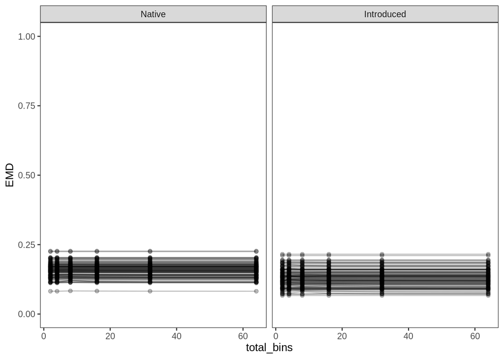

```r
# glimpse(emd_res)

# First check how consistent the EMD results are across resampling iterations as well as bins

# Individual scale
emd_res %>%
  dplyr::filter(social_scale == "Individual") %>%
  ggplot(aes(x = total_bins, y = EMD)) +
  geom_point(color = scales::alpha("black", 0.25)) +
  geom_line(aes(group = iter), color = scales::alpha("black", 0.25)) +
  facet_wrap(~ range) +
  scale_y_continuous(limits = c(0, 1)) +
  theme_bw() +
  theme(
    panel.grid.major = element_blank(),
    panel.grid.minor = element_blank()
  )
```

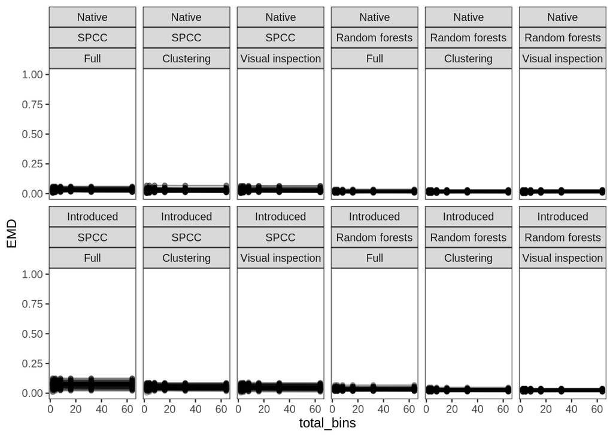

```r
# Site scale
emd_res %>%
  dplyr::filter(social_scale == "Site") %>%
  ggplot(aes(x = total_bins, y = EMD)) +
  geom_point(color = scales::alpha("black", 0.25)) +
  geom_line(aes(group = iter), color = scales::alpha("black", 0.25)) +
  facet_wrap(range + similarity_method ~ dataset, nrow = 2) +
  scale_y_continuous(limits = c(0, 1)) +
  theme_bw() +
  theme(
    panel.grid.major = element_blank(),
    panel.grid.minor = element_blank()
  )
```

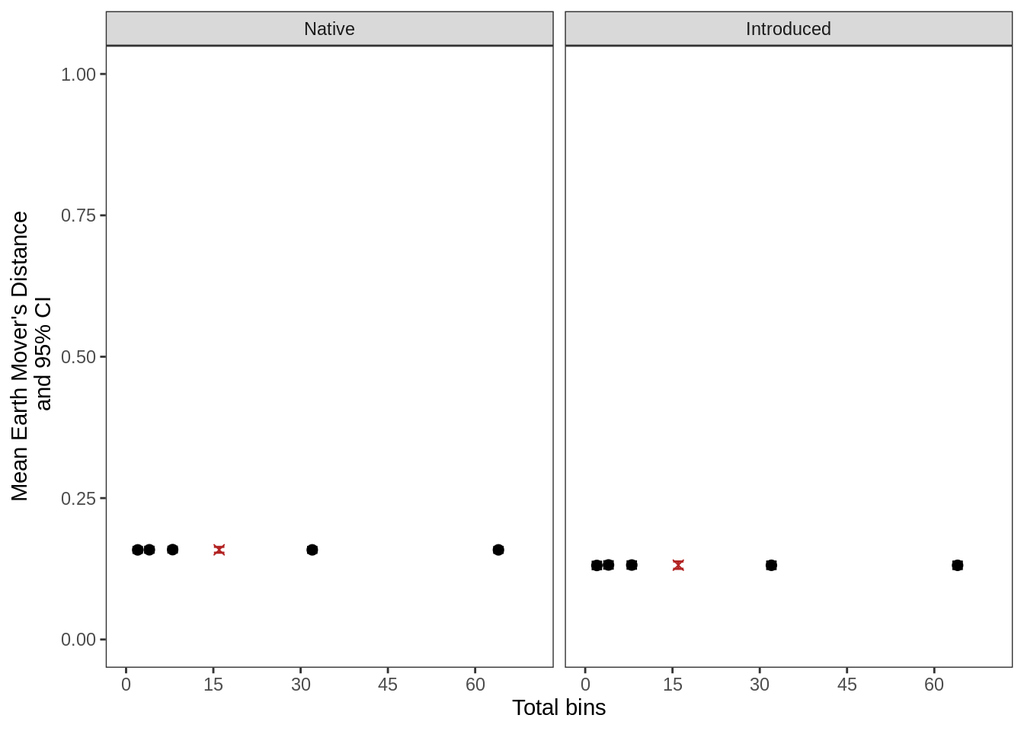

```r
# If results are consistent across bins within resampling iterations, then select one bin number and summarise across iterations to get means and 95% CIs across social scales, ranges, datasets, similarity methods. Make plots for the appendix

# Individual scale: results for all bins summarized across resampling iterations. Coloring the results to highlight the bin number used in the main table
emd_res %>%
  dplyr::filter(social_scale == "Individual") %>%
  dplyr::mutate(range = factor(range, levels = c("Native", "Introduced"))) %>%
  group_by(range, total_bins) %>%
  dplyr::summarise(
    mean = Rmisc::CI(EMD, ci = 0.95)[["mean"]],
    u_CI = Rmisc::CI(EMD, ci = 0.95)[["upper"]],
    l_CI = Rmisc::CI(EMD, ci = 0.95)[["lower"]]
  ) %>%
  dplyr::mutate(
    main_table = ifelse(total_bins == 16, "yes", "no"),
    main_table = factor(main_table, levels = c("yes", "no"))
  ) %>%
  ggplot(aes(x = total_bins, y = mean, color = main_table, fill = main_table, shape = main_table)) +
  geom_point(size = 2) +
  geom_errorbar(aes(ymin = l_CI, ymax = u_CI)) +
  scale_color_manual(values = c("firebrick", "black")) +
  scale_fill_manual(values = c("firebrick", "black")) +
  scale_shape_manual(values = c(4, 21)) +
  guides(color = "none", fill = "none", shape = "none") +
  facet_wrap(~ range) +
  scale_y_continuous(limits = c(0, 1)) +
  scale_x_continuous(limits = c(0, 70), breaks = seq(0, 70, 15), labels = seq(0, 70, 15)) +
  ylab("Mean Earth Mover's Distance\n and 95% CI") +
  xlab("Total bins") +
  theme_bw() +
  theme(
    panel.grid.major = element_blank(),
    panel.grid.minor = element_blank()
  )
```

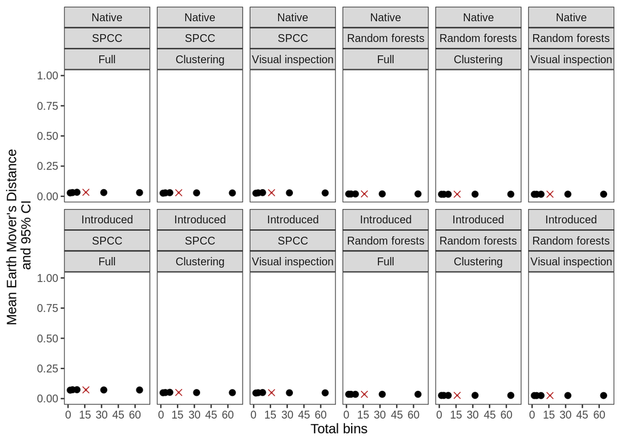

```r
# ggsave(file.path(gpath, "HierarchicalMapping_EMD_binSummary_IndivScale.tiff"), units = "in", width = 5, height = 2.5, dpi = 300)

# Site scale: results for all bins summarized across resampling iterations. Also coloring the results to highlight the bin number used in the main table
emd_res %>%
  dplyr::filter(social_scale == "Site") %>%
  dplyr::mutate(
    range = factor(range, levels = c("Native", "Introduced")),
    similarity_method = factor(similarity_method, levels = c("SPCC", "Random forests")),
    dataset = factor(dataset, levels = c("Full", "Clustering", "Visual inspection"))
  ) %>%
  group_by(range, similarity_method, dataset, total_bins) %>%
  dplyr::summarise(
    mean = Rmisc::CI(EMD, ci = 0.95)[["mean"]],
    u_CI = Rmisc::CI(EMD, ci = 0.95)[["upper"]],
    l_CI = Rmisc::CI(EMD, ci = 0.95)[["lower"]]
  ) %>%
  dplyr::mutate(
    main_table = ifelse(total_bins == 16, "yes", "no"),
    main_table = factor(main_table, levels = c("yes", "no"))
  ) %>%
  ggplot(aes(x = total_bins, y = mean, color = main_table, fill = main_table, shape = main_table)) +
  geom_point(size = 2) +
  geom_errorbar(aes(ymin = l_CI, ymax = u_CI)) +
  scale_color_manual(values = c("firebrick", "black")) +
  scale_fill_manual(values = c("firebrick", "black")) +
  scale_shape_manual(values = c(4, 21)) +
  guides(color = "none", fill = "none", shape = "none") +
  facet_wrap(range + similarity_method ~ dataset, nrow = 2) +
  scale_y_continuous(limits = c(0, 1)) +
  scale_x_continuous(limits = c(0, 70), breaks = seq(0, 70, 15), labels = seq(0, 70, 15)) +
  ylab("Mean Earth Mover's Distance\n and 95% CI") +
  xlab("Total bins") +
  theme_bw() +
  theme(
    panel.grid.major = element_blank(),
    panel.grid.minor = element_blank()
  )
```

```r
# ggsave(file.path(gpath, "HierarchicalMapping_EMD_binSummary_SiteScale.tiff"), units = "in", width = 7.5, height = 5, dpi = 300)
```

Make a figure and table for the main text after validation. Use a single total bin number for results here.

```r
# Use an intermediate bin number since results are consistent across bins (within sampling iterations). I decided to go with 16 bins for the results that will go into a main table

emd_res %>%
  pull(total_bins) %>%
  unique()
```

```
## [1]  2  4  8 16 32 64
```

```r
# Make a plot for the main text, use the full site scale dataset only
sum_stats_df <- emd_res %>%
  dplyr::filter(total_bins == 16) %>%
  group_by(social_scale, range, dataset, similarity_method, total_bins) %>%
  dplyr::summarise(
    mean = round(Rmisc::CI(EMD, ci = 0.95)[["mean"]], 3),
    l_CI = round(Rmisc::CI(EMD, ci = 0.95)[["lower"]], 3),
    u_CI = round(Rmisc::CI(EMD, ci = 0.95)[["upper"]], 3)
  ) %>%
  ungroup() %>%
  dplyr::filter(dataset == "Full" | is.na(dataset)) %>%
  dplyr::arrange(.,
    social_scale, similarity_method, range, dataset
  ) %>%
  dplyr::select(social_scale, similarity_method, range, dataset, mean, l_CI, u_CI, total_bins) %>%
  dplyr::mutate(
    range = paste(range, "range", sep = " "),
    range = factor(range, levels = c("Native range", "Introduced range")),
    # Make a new column of the social scale and similarity method combined for the x-axis
    social_scale_simMeth = paste(social_scale, similarity_method, sep = "-"),
    social_scale_simMeth = factor(social_scale_simMeth, levels = c("Individual-SPCC", "Site-Random forests", "Site-SPCC"))
  )

glimpse(sum_stats_df)
```

```
## Rows: 6
## Columns: 9
## $ social_scale         <fct> Individual, Individual, Site, Site, Site, Site
## $ similarity_method    <fct> SPCC, SPCC, SPCC, SPCC, Random forests, Random fo…
## $ range                <fct> Native range, Introduced range, Native range, Int…
## $ dataset              <fct> NA, NA, Full, Full, Full, Full
## $ mean                 <dbl> 0.159, 0.131, 0.033, 0.073, 0.020, 0.036
## $ l_CI                 <dbl> 0.153, 0.125, 0.031, 0.068, 0.019, 0.034
## $ u_CI                 <dbl> 0.164, 0.138, 0.035, 0.077, 0.021, 0.038
## $ total_bins           <int> 16, 16, 16, 16, 16, 16
## $ social_scale_simMeth <fct> Individual-SPCC, Individual-SPCC, Site-SPCC, Site…
```

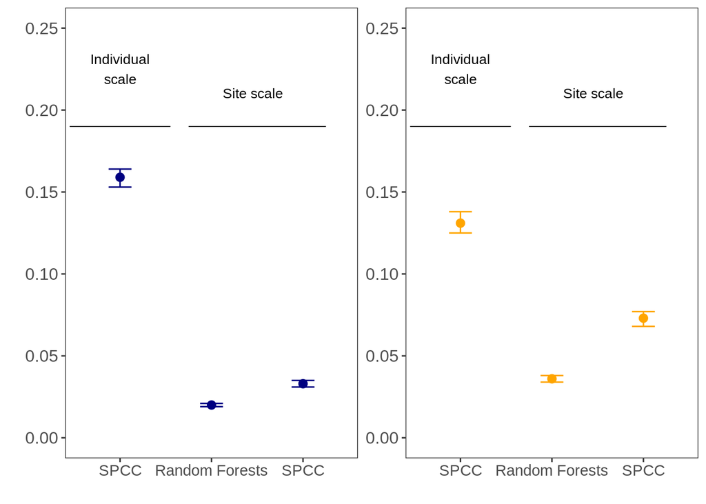

```r
# levels(sum_stats_df$social_scale_simMeth)

clrs <- c("navy", "orange")

ggplot(data = sum_stats_df,
       aes(x = social_scale_simMeth, y = mean, color = range, fill = range)) +
  geom_point(size = 2.5) +
  geom_errorbar(aes(ymin = l_CI, ymax = u_CI), width = 0.25) +
  scale_color_manual(values = clrs) +
  scale_fill_manual(values = scales::alpha(clrs, 0.65)) +
  guides(color = "none", fill = "none", linetype = "none") +
  # Free the y-axes to have y-axis text per panel
  facet_wrap(~ range, nrow = 1, scales = "free_y") +
  scale_y_continuous(limits = c(0, 0.25)) +
  # Fix x-axis labels to show the similarity method only
  scale_x_discrete(labels = c("SPCC", "Random Forests", "SPCC")) +
  # Add horizontal lines and labels to annotate social scales
  # Annotation line above the individual scale results
  geom_segment(aes(x = 0.45, xend = 1.55, y = 0.19, yend = 0.19), color = "black", linetype = "solid", linewidth = 0.15) +
  # Annotation line above the site scale results
  geom_segment(aes(x = 1.75, xend = 3.25, y = 0.19, yend = 0.19), color = "black", linetype = "solid", linewidth = 0.15) +
  # Annotation text above the individual scale results
  annotate("text", x = 1, y = 0.225, label = "Individual\nscale", size = 3.5) +
  # Annotation text above the site scale results
  annotate("text", x = 2.45, y = 0.21, label = "Site scale", size = 3.5) +
  ylab("") +
  xlab("") +
  theme_bw() +
  theme(
    panel.grid.major = element_blank(),
    panel.grid.minor = element_blank(),
    strip.background = element_blank(),
    strip.text = element_blank(),
    axis.text.y = element_text(size = 12),
    axis.text.x = element_text(size = 11)
  )
```

```r
# ggsave(file.path(gpath, "HierarchicalMapping_RangeComparison_EarthMoversDist.jpeg"), units = "in", width = 6.5, height = 2)

# Making a table to be used in the main text
emd_res %>%
  dplyr::filter(total_bins == 16) %>%
  group_by(social_scale, range, dataset, similarity_method, total_bins) %>%
  dplyr::summarise(
    mean = round(Rmisc::CI(EMD, ci = 0.95)[["mean"]], 3),
    l_CI = round(Rmisc::CI(EMD, ci = 0.95)[["lower"]], 3),
    u_CI = round(Rmisc::CI(EMD, ci = 0.95)[["upper"]], 3)
  ) %>%
  # Arrange to match ordering of Table 1 in the main text
  dplyr::arrange(.,
    social_scale, similarity_method, range, dataset
  ) %>%
  dplyr::select(social_scale, similarity_method, range, dataset, mean, l_CI, u_CI, total_bins) %>%
  kable(align = "c")
```

| social_scale | similarity_method | range | dataset | mean | l_CI | u_CI | total_bins |
| --- | --- | --- | --- | --- | --- | --- | --- |
| Individual | SPCC | Native | NA | 0.159 | 0.153 | 0.164 | 16 |
| Individual | SPCC | Introduced | NA | 0.131 | 0.125 | 0.138 | 16 |
| Site | SPCC | Native | Full | 0.033 | 0.031 | 0.035 | 16 |
| Site | SPCC | Native | Clustering | 0.030 | 0.027 | 0.032 | 16 |
| Site | SPCC | Native | Visual inspection | 0.030 | 0.027 | 0.032 | 16 |
| Site | SPCC | Introduced | Full | 0.073 | 0.068 | 0.077 | 16 |
| Site | SPCC | Introduced | Clustering | 0.051 | 0.048 | 0.054 | 16 |
| Site | SPCC | Introduced | Visual inspection | 0.049 | 0.046 | 0.053 | 16 |
| Site | Random forests | Native | Full | 0.020 | 0.019 | 0.021 | 16 |
| Site | Random forests | Native | Clustering | 0.017 | 0.016 | 0.019 | 16 |
| Site | Random forests | Native | Visual inspection | 0.017 | 0.016 | 0.019 | 16 |
| Site | Random forests | Introduced | Full | 0.036 | 0.034 | 0.038 | 16 |
| Site | Random forests | Introduced | Clustering | 0.027 | 0.025 | 0.028 | 16 |
| Site | Random forests | Introduced | Visual inspection | 0.026 | 0.024 | 0.027 | 16 |

# Introduced range temporal analysis

Calculate Earth Mover’s Distance for the site scale in the introduced range over time. This calculation should also be performed for each site scale dataset and similarity method in each city and year of interest.

Read in the 3 site scale datasets for temporal comparisons and show sample sizes over time per city.

```r
site_scale_nf_temp <- readRDS(file.path(path, "site_scale_nf_temp.RDS"))
glimpse(site_scale_nf_temp)
```

```
## Rows: 531
## Columns: 26
## $ sound.files          <chr> "2011_02_15_ELEM_WRIG1013_2.WAV", "2011_02_15_ELE…
## $ selec                <dbl> 1, 1, 1, 1, 1, 1, 1, 1, 1, 1, 1, 1, 1, 1, 1, 1, 1…
## $ start                <dbl> 0.05109020, 0.05015252, 0.04765835, 0.04157400, 0…
## $ end                  <dbl> 0.2410596, 0.2281542, 0.2292002, 0.2426955, 0.240…
## $ date                 <date> 2011-02-15, 2011-02-15, 2011-02-15, 2011-02-15, …
## $ range                <chr> "Introduced", "Introduced", "Introduced", "Introd…
## $ social_scale         <chr> "Site", "Site", "Site", "Site", "Site", "Site", "…
## $ site                 <chr> "ELEM", "ELEM", "ELEM", "ELEM", "ELEM", "ELEM", "…
## $ Bird_ID              <chr> NA, NA, NA, NA, NA, NA, NA, NA, NA, NA, NA, NA, N…
## $ lat                  <dbl> 30.26028, 30.26028, 30.26028, 30.26028, 30.26028,…
## $ lon                  <dbl> -97.71833, -97.71833, -97.71833, -97.71833, -97.7…
## $ Visual_quality_score <fct> M, H, M, M, M, M, M, M, M, M, M, H, M, M, H, M, M…
## $ Overlapping_signal   <fct> N, N, N, N, N, N, N, N, N, N, N, N, N, N, N, N, N…
## $ Truncated            <chr> "N", "N", "N", "N", "N", "N", "N", "N", "N", "N",…
## $ tailored             <fct> y, y, y, y, y, y, y, y, y, y, y, y, y, y, y, y, y…
## $ prev_SNR             <dbl> NA, NA, NA, NA, NA, NA, NA, NA, NA, NA, NA, NA, N…
## $ SNR_margin_works     <chr> "Y", "Y", "Y", "Y", "Y", "Y", "Y", "Y", "Y", "Y",…
## $ SNR_before_only      <chr> NA, NA, NA, NA, NA, NA, NA, NA, NA, NA, NA, NA, N…
## $ old.sound.file.name  <chr> "2011_02_15_ELEM_WRIG1013_2.WAV", "2011_02_15_ELE…
## $ SNR                  <dbl> 7.357203, 17.122423, 20.295117, 15.881464, 14.575…
## $ region               <chr> "Southwest", "Southwest", "Southwest", "Southwest…
## $ country              <chr> "United States", "United States", "United States"…
## $ site_year            <chr> "ELEM_2011", "ELEM_2011", "ELEM_2011", "ELEM_2011…
## $ year                 <chr> "2011", "2011", "2011", "2011", "2011", "2011", "…
## $ dept_state           <chr> "Texas", "Texas", "Texas", "Texas", "Texas", "Tex…
## $ introduced_city      <chr> "Austin", "Austin", "Austin", "Austin", "Austin",…
```

```r
site_scale_nf_temp %>%
  group_by(year, introduced_city) %>%
  dplyr::summarise(
    n = n()
  )
```

```
## # A tibble: 5 × 3
## # Groups:   year [3]
##   year  introduced_city     n
##   <chr> <chr>           <int>
## 1 2004  Austin             93
## 2 2004  New Orleans        49
## 3 2011  Austin             65
## 4 2011  New Orleans        29
## 5 2019  Austin            295
```

```r
site_scale_cf_temp <- readRDS(file.path(path, "site_scale_cf_temp.RDS"))
glimpse(site_scale_cf_temp)
```

```
## Rows: 172
## Columns: 26
## $ sound.files          <chr> "2011_02_15_ELEM_WRIG1013_2.WAV", "2011_02_15_ELE…
## $ selec                <dbl> 1, 1, 1, 1, 1, 1, 1, 1, 1, 1, 1, 1, 1, 1, 1, 1, 1…
## $ start                <dbl> 0.05109020, 0.05015252, 0.04765835, 0.04157400, 0…
## $ end                  <dbl> 0.2410596, 0.2281542, 0.2292002, 0.2426955, 0.240…
## $ date                 <date> 2011-02-15, 2011-02-15, 2011-02-15, 2011-02-15, …
## $ range                <chr> "Introduced", "Introduced", "Introduced", "Introd…
## $ social_scale         <chr> "Site", "Site", "Site", "Site", "Site", "Site", "…
## $ site                 <chr> "ELEM", "ELEM", "ELEM", "ELEM", "ELEM", "ELEM", "…
## $ Bird_ID              <chr> NA, NA, NA, NA, NA, NA, NA, NA, NA, NA, NA, NA, N…
## $ lat                  <dbl> 30.26028, 30.26028, 30.26028, 30.26028, 30.26028,…
## $ lon                  <dbl> -97.71833, -97.71833, -97.71833, -97.71833, -97.7…
## $ Visual_quality_score <fct> M, H, M, M, M, M, M, M, H, M, M, M, M, M, H, M, H…
## $ Overlapping_signal   <fct> N, N, N, N, N, N, N, N, N, N, N, N, N, N, N, N, N…
## $ Truncated            <chr> "N", "N", "N", "N", "N", "N", "N", "N", "N", "N",…
## $ tailored             <fct> y, y, y, y, y, y, y, y, y, y, y, y, y, y, y, y, y…
## $ prev_SNR             <dbl> NA, NA, NA, NA, NA, NA, NA, NA, NA, NA, NA, NA, N…
## $ SNR_margin_works     <chr> "Y", "Y", "Y", "Y", "Y", "Y", "Y", "Y", "Y", "Y",…
## $ SNR_before_only      <chr> NA, NA, NA, NA, NA, NA, NA, NA, NA, NA, NA, NA, N…
## $ old.sound.file.name  <chr> "2011_02_15_ELEM_WRIG1013_2.WAV", "2011_02_15_ELE…
## $ SNR                  <dbl> 7.357203, 17.122423, 20.295117, 15.881464, 14.575…
## $ region               <chr> "Southwest", "Southwest", "Southwest", "Southwest…
## $ country              <chr> "United States", "United States", "United States"…
## $ site_year            <chr> "ELEM_2011", "ELEM_2011", "ELEM_2011", "ELEM_2011…
## $ year                 <chr> "2011", "2011", "2011", "2011", "2011", "2011", "…
## $ dept_state           <chr> "Texas", "Texas", "Texas", "Texas", "Texas", "Tex…
## $ introduced_city      <chr> "Austin", "Austin", "Austin", "Austin", "Austin",…
```

```r
site_scale_cf_temp %>%
  group_by(year, introduced_city) %>%
  dplyr::summarise(
    n = n()
  )
```

```
## # A tibble: 5 × 3
## # Groups:   year [3]
##   year  introduced_city     n
##   <chr> <chr>           <int>
## 1 2004  Austin             20
## 2 2004  New Orleans        25
## 3 2011  Austin             54
## 4 2011  New Orleans        17
## 5 2019  Austin             56
```

```r
site_scale_vf_temp <- readRDS(file.path(path, "site_scale_vf_temp.RDS"))
glimpse(site_scale_vf_temp)
```

```
## Rows: 198
## Columns: 26
## $ sound.files          <chr> "2011_02_15_ELEM_WRIG1013_2.WAV", "2011_02_15_ELE…
## $ selec                <dbl> 1, 1, 1, 1, 1, 1, 1, 1, 1, 1, 1, 1, 1, 1, 1, 1, 1…
## $ start                <dbl> 0.05109020, 0.05015252, 0.04765835, 0.04157400, 0…
## $ end                  <dbl> 0.2410596, 0.2281542, 0.2292002, 0.2426955, 0.240…
## $ date                 <date> 2011-02-15, 2011-02-15, 2011-02-15, 2011-02-15, …
## $ range                <chr> "Introduced", "Introduced", "Introduced", "Introd…
## $ social_scale         <chr> "Site", "Site", "Site", "Site", "Site", "Site", "…
## $ site                 <chr> "ELEM", "ELEM", "ELEM", "ELEM", "ELEM", "ELEM", "…
## $ Bird_ID              <chr> NA, NA, NA, NA, NA, NA, NA, NA, NA, NA, NA, NA, N…
## $ lat                  <dbl> 30.26028, 30.26028, 30.26028, 30.26028, 30.26028,…
## $ lon                  <dbl> -97.71833, -97.71833, -97.71833, -97.71833, -97.7…
## $ Visual_quality_score <fct> M, H, M, M, M, M, M, M, H, M, M, M, M, M, H, M, H…
## $ Overlapping_signal   <fct> N, N, N, N, N, N, N, N, N, N, N, N, N, N, N, N, N…
## $ Truncated            <chr> "N", "N", "N", "N", "N", "N", "N", "N", "N", "N",…
## $ tailored             <fct> y, y, y, y, y, y, y, y, y, y, y, y, y, y, y, y, y…
## $ prev_SNR             <dbl> NA, NA, NA, NA, NA, NA, NA, NA, NA, NA, NA, NA, N…
## $ SNR_margin_works     <chr> "Y", "Y", "Y", "Y", "Y", "Y", "Y", "Y", "Y", "Y",…
## $ SNR_before_only      <chr> NA, NA, NA, NA, NA, NA, NA, NA, NA, NA, NA, NA, N…
## $ old.sound.file.name  <chr> "2011_02_15_ELEM_WRIG1013_2.WAV", "2011_02_15_ELE…
## $ SNR                  <dbl> 7.357203, 17.122423, 20.295117, 15.881464, 14.575…
## $ region               <chr> "Southwest", "Southwest", "Southwest", "Southwest…
## $ country              <chr> "United States", "United States", "United States"…
## $ site_year            <chr> "ELEM_2011", "ELEM_2011", "ELEM_2011", "ELEM_2011…
## $ year                 <chr> "2011", "2011", "2011", "2011", "2011", "2011", "…
## $ dept_state           <chr> "Texas", "Texas", "Texas", "Texas", "Texas", "Tex…
## $ introduced_city      <chr> "Austin", "Austin", "Austin", "Austin", "Austin",…
```

```r
site_scale_vf_temp %>%
  group_by(year, introduced_city) %>%
  dplyr::summarise(
    n = n()
  )
```

```
## # A tibble: 5 × 3
## # Groups:   year [3]
##   year  introduced_city     n
##   <chr> <chr>           <int>
## 1 2004  Austin             37
## 2 2004  New Orleans        18
## 3 2011  Austin             43
## 4 2011  New Orleans        17
## 5 2019  Austin             83
```

Did all sites per dataset, year, and city have 5 calls? Checking sample sizes used for the analyses below.

```r
# Yes for the full dataset
site_scale_nf_temp %>%
  group_by(year, introduced_city, site) %>%
  dplyr::summarise(
    n = n()
  ) %>%
  dplyr::filter(n < 5)
```

```
## # A tibble: 0 × 4
## # Groups:   year, introduced_city [0]
## # ℹ 4 variables: year <chr>, introduced_city <chr>, site <chr>, n <int>
```

```r
# The number of sites used per year for the full dataset
site_scale_nf_temp %>%
  group_by(year, introduced_city, site) %>%
  dplyr::summarise(
    n = n()
  ) %>%
  dplyr::filter(n >= 5) %>%
  dplyr::summarise(
    n_sites = length(site)
  )
```

```
## # A tibble: 5 × 3
## # Groups:   year [3]
##   year  introduced_city n_sites
##   <chr> <chr>             <int>
## 1 2004  Austin                3
## 2 2004  New Orleans           3
## 3 2011  Austin                5
## 4 2011  New Orleans           2
## 5 2019  Austin                6
```

```r
# For the clustering-filtered dataset, this sample size restriction led to dropping 1 site in each city in 2004, and 1 in Austin in 2019
site_scale_cf_temp %>%
  group_by(year, introduced_city, site) %>%
  dplyr::summarise(
    n = n()
  ) %>%
  dplyr::filter(n < 5)
```

```
## # A tibble: 3 × 4
## # Groups:   year, introduced_city [3]
##   year  introduced_city site      n
##   <chr> <chr>           <chr> <int>
## 1 2004  Austin          VALL      4
## 2 2004  New Orleans     BALL      4
## 3 2019  Austin          MANO      4
```

```r
# The number of sites used per year for the clustering-filtered dataset
site_scale_cf_temp %>%
  group_by(year, introduced_city, site) %>%
  dplyr::summarise(
    n = n()
  ) %>%
  dplyr::filter(n >= 5) %>%
  dplyr::summarise(
    n_sites = length(site)
  )
```

```
## # A tibble: 5 × 3
## # Groups:   year [3]
##   year  introduced_city n_sites
##   <chr> <chr>             <int>
## 1 2004  Austin                2
## 2 2004  New Orleans           2
## 3 2011  Austin                5
## 4 2011  New Orleans           2
## 5 2019  Austin                5
```

```r
# For the visual classification-filtered dataset, this sample size restriction led to dropping 1 site in New Orleans in 2004, and 1 site in Austin in 2019
site_scale_vf_temp %>%
  group_by(year, introduced_city, site) %>%
  dplyr::summarise(
    n = n()
  ) %>%
  dplyr::filter(n < 5)
```

```
## # A tibble: 2 × 4
## # Groups:   year, introduced_city [2]
##   year  introduced_city site      n
##   <chr> <chr>           <chr> <int>
## 1 2004  New Orleans     FOLS      3
## 2 2019  Austin          MANO      3
```

```r
# The number of sites used per year for the visual classification-filtered dataset
site_scale_vf_temp %>%
  group_by(year, introduced_city, site) %>%
  dplyr::summarise(
    n = n()
  ) %>%
  dplyr::filter(n >= 5) %>%
  dplyr::summarise(
    n_sites = length(site)
  )
```

```
## # A tibble: 5 × 3
## # Groups:   year [3]
##   year  introduced_city n_sites
##   <chr> <chr>             <int>
## 1 2004  Austin                3
## 2 2004  New Orleans           2
## 3 2011  Austin                5
## 4 2011  New Orleans           2
## 5 2019  Austin                5
```

Here I randomly sampled 5 calls per site with more than 5 calls but I randomly sampled 2 sites per city-year here, given that we generally did not sample 5 different sites in each city-year.

```r
# Iterate over cities, years, site scale datasets, and similarity methods to perform these calculations

# Cities over which to iterate
cities <- c("Austin", "New Orleans")

# Years over which to iterate, per each city
years <- list(
  c(2004, 2011, 2019),
  c(2004, 2011)
)

sim_meth <- c("SPCC", "Random forests")
data_subset <- c("Full", "Clustering", "Visual inspection")

mat_list <- list(xc_mat_spec, vp_prox_mat)
df_list <- list(site_scale_nf_temp, site_scale_vf_temp, site_scale_cf_temp)

# Site and call resampling iterations
iteratns <- 100

# Arguments for the Earth Mover's Distance function, same as for the individual scale
distr_types <- c("within", "among")

total_bins <- 2 ^ seq(1, 6, 1)
# total_bins # [1] 2  4  8 16 32 64
# length(total_bins) # [1] 6

bounds <- c(0, 1)

# The number of randomly sampled sites
rn <- 2

# The number of randomly sampled calls per site (for sites with more than this number of calls)
rc <- 5

# A txt file will be populated by appending results
file_nm <- "resampled_EMD_site_scale_introducedTemporal.txt"

file.remove(file.path(path, file_nm)) # remove previous versions as needed

# y <- 1 # Testing
# m <- 1
# s <- 1
# z <- 1
invisible(pblapply(1:length(cities), function(m){

  city <- cities[m]
  years_tmp <- years[[m]]

  lapply(1:length(years_tmp), function(y){

    yr <- years_tmp[y]

    lapply(1:length(sim_meth), function(s){

      lapply(1:length(data_subset), function(z){

        # Initialize the data frame of calls for the given site scale dataset
        # Also filter by the given city and year
        tmp_df <- df_list[[z]] %>%
          dplyr::filter(introduced_city == city) %>%
          dplyr::filter(year == yr)

        # glimpse(tmp_df)

        # Checking, looks good
        # tmp_df %>%
          # distinct(range, introduced_city, year)

        # For each range, iterate over resampling iterations (5 randomly sampled individuals and 5 randomly sampled calls per individual, all without replacement)
        lapply(1:iteratns, function(p){

          # Randomly sample 2 sites per range without replacement
          # These sites need to be pulled from those that have 5 calls or more
          sites <- tmp_df %>%
            group_by(site_year) %>%
            dplyr::summarise(n_calls = n()) %>%
            dplyr::filter(n_calls >= rc) %>%
            pull(site_year) %>%
            unique() %>%
            sample(., size = rn, replace = FALSE)

          # sites

          # Then among these, randomly sample 5 calls for each site that has more than 5 calls
          # First filter by the sites that meet this condition
          calls_tmp_df <- tmp_df %>%
            dplyr::filter(site_year %in% sites)

          # glimpse(calls_tmp_df)

          r_calls_tmp_df <- calls_tmp_df %>%
            group_by(site_year) %>%
            dplyr::summarise(n_calls = n()) %>%
            dplyr::filter(n_calls > rc) %>%
            inner_join(
              calls_tmp_df,
              by = "site_year"
            ) %>%
            dplyr::select(-c(n_calls)) %>%
            # Do the random sampling by site (without replacement)
            group_by(site_year) %>%
            dplyr::sample_n(., size = rc, replace = FALSE) %>%
            ungroup() %>%
            # Add back the calls for site(s) with only 5 calls
            bind_rows(
              calls_tmp_df %>%
                group_by(site_year) %>%
                dplyr::summarise(n_calls = n()) %>%
                dplyr::filter(n_calls == rc) %>%
                inner_join(
                  calls_tmp_df,
                  by = "site_year"
                ) %>%
                dplyr::select(-c(n_calls)) %>%
                ungroup()
            )

          # glimpse(r_calls_tmp_df)

          # Checking, looks good
          # r_calls_tmp_df %>%
          #   group_by(site_year) %>%
          #   dplyr::summarise(n_calls = n())

          # Then get all of the calls for the given iteration
          calls <- r_calls_tmp_df %>%
            pull(sound.files)

          # head(calls)
          # length(calls)

          # Initialize the correct similarity matrix
          tmp_sim_mat <- mat_list[[s]]

          # Get the similarity values representing all unique pairwise comparisons within and among individuals for these calls
          tmp_sim_df <- extract_simValues(sim_mat = tmp_sim_mat, calls = calls, species = "monk parakeet", social_scale = "Site", dataset = data_subset[z], similarity_method = sim_meth[s], city_year = unique(paste(tmp_df$introduced_city, tmp_df$year, sep = "_")), metadata_df = nat_int_est, analysis_type = "EMD")

          # glimpse(tmp_sim_df)

          # 25 among values and 20 within values for the random sampling below in the Earth Mover's Distance calculations, looks good
          # tmp_sim_df %>%
          #   group_by(type) %>%
          #   dplyr::summarise(
          #     n = n()
          #   )

          # Do the Earth Mover's Distance calculations over bin numbers and resampling
          emd_res_df <- resampled_earthMoversDistance(sim_df = tmp_sim_df, distr_types = distr_types, total_bins = total_bins, bounds = bounds)

          # glimpse(emd_res_df)

          # If on the first iteration, write a new file
          if(m == 1 & y == 1 & s == 1 & z == 1 & p == 1){
            write.table(
              emd_res_df %>%
                dplyr::mutate(iter = p), file = file.path(path, file_nm), sep = ",", col.names = TRUE, quote = FALSE, row.names = FALSE)

            # Append to the existing file in subsequent iterations
          } else {
            write.table(
              emd_res_df %>%
                dplyr::mutate(iter = p), file = file.path(path, file_nm), sep = ",", col.names = FALSE, quote = FALSE, row.names = FALSE, append = TRUE)
          }

        })

      })

    })

  })

}))

# warnings? None with 5000 max iterations

# 5 resampling iterations took a 4 minutes 10 secs
# 100 resampling iterations took 1 hour and 22 mins 53 secs
```

## Temporal comparison results

Read in the Earth Mover’s distance results for the temporal introduced range analysis.

```r
emd_res <- read.table(file.path(path, "resampled_EMD_site_scale_introducedTemporal.txt"), sep = ",", header = TRUE) %>%
  dplyr::mutate(
    dataset = factor(dataset, levels = c("Full", "Clustering", "Visual inspection")),
    similarity_method = factor(similarity_method, levels = c("SPCC", "Random forests"))
  )

glimpse(emd_res)
```

```
## Rows: 18,000
## Columns: 10
## $ social_scale      <chr> "Site", "Site", "Site", "Site", "Site", "Site", "Sit…
## $ range             <chr> "Introduced", "Introduced", "Introduced", "Introduce…
## $ total_bins        <int> 2, 4, 8, 16, 32, 64, 2, 4, 8, 16, 32, 64, 2, 4, 8, 1…
## $ n_within          <int> 20, 20, 20, 20, 20, 20, 20, 20, 20, 20, 20, 20, 20, …
## $ n_among           <int> 20, 20, 20, 20, 20, 20, 20, 20, 20, 20, 20, 20, 20, …
## $ EMD               <dbl> 0.01930929, 0.01930926, 0.04228404, 0.04516372, 0.04…
## $ dataset           <fct> Full, Full, Full, Full, Full, Full, Full, Full, Full…
## $ similarity_method <fct> SPCC, SPCC, SPCC, SPCC, SPCC, SPCC, SPCC, SPCC, SPCC…
## $ city_year         <chr> "Austin_2004", "Austin_2004", "Austin_2004", "Austin…
## $ iter              <int> 1, 1, 1, 1, 1, 1, 2, 2, 2, 2, 2, 2, 3, 3, 3, 3, 3, 3…
```

```r
# For Austin: 1 social scale, 1 range, 1 city, 3 years, 2 similarity methods, 3 datasets, 6 total bin values, 100 resampling iterations. This should have 10,800 rows, looks good
emd_res %>%
  dplyr::filter(grepl("Austin", city_year)) %>%
  nrow()
```

```
## [1] 10800
```

```r
# There should be 100 iterations for each bin, yes
emd_res %>%
  dplyr::filter(grepl("Austin", city_year)) %>%
  group_by(city_year, similarity_method, dataset, total_bins) %>%
  dplyr::summarise(n = n()) %>%
  pull(n) %>%
  unique()
```

```
## [1] 100
```

```r
# There are 108 unique combinations here, looks good
emd_res %>%
  dplyr::filter(grepl("Austin", city_year)) %>%
  distinct(city_year, similarity_method, dataset, total_bins) %>%
  nrow()
```

```
## [1] 108
```

```r
  # View()

# For New Orleans: 1 social scale, 1 range, 1 city, 2 years, 2 similarity methods, 3 datasets, 6 total bin values, 100 resampling iterations. This should have 7200 rows, looks good
emd_res %>%
  dplyr::filter(grepl("New Orleans", city_year)) %>%
  nrow()
```

```
## [1] 7200
```

```r
# There are 72 unique combinations here, looks good
emd_res %>%
  dplyr::filter(grepl("New Orleans", city_year)) %>%
  distinct(city_year, similarity_method, dataset, total_bins) %>%
  nrow()
```

```
## [1] 72
```

```r
# Also looks good (the number of similarity values used for each distribution in EMD calculations)
emd_res %>%
  distinct(n_within, n_among)
```

```
##   n_within n_among
## 1       20      20
```

Summarize the Earth Mover’s distance results for this temporal analysis. Make validation figures.

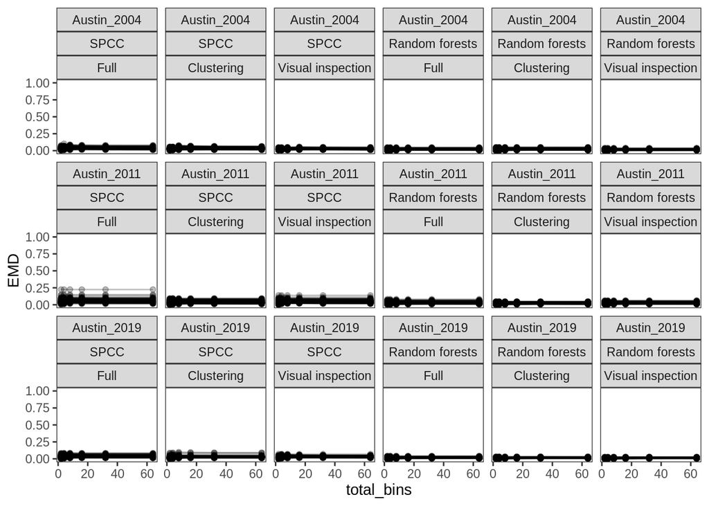

```r
# glimpse(emd_res)

# First check how consistent the EMD results are across resampling iterations as well as bins

# Austin
emd_res %>%
  dplyr::filter(grepl("Austin", city_year)) %>%
  ggplot(aes(x = total_bins, y = EMD)) +
  geom_point(color = scales::alpha("black", 0.25)) +
  geom_line(aes(group = iter), color = scales::alpha("black", 0.25)) +
  facet_wrap(city_year + similarity_method ~ dataset, nrow = 3) +
  scale_y_continuous(limits = c(0, 1)) +
  theme_bw() +
  theme(
    panel.grid.major = element_blank(),
    panel.grid.minor = element_blank()
  )
```

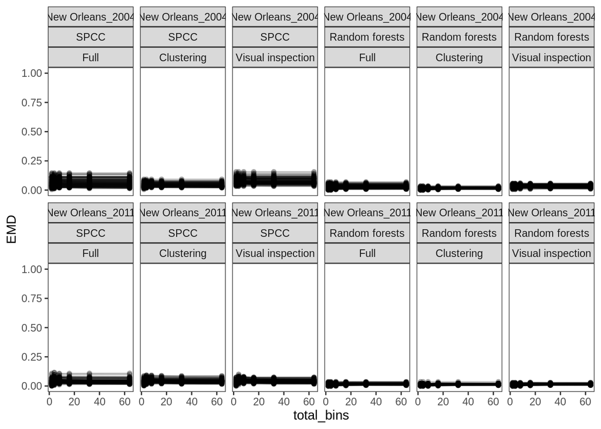

```r
# New Orleans
emd_res %>%
  dplyr::filter(grepl("New Orleans", city_year)) %>%
  ggplot(aes(x = total_bins, y = EMD)) +
  geom_point(color = scales::alpha("black", 0.25)) +
  geom_line(aes(group = iter), color = scales::alpha("black", 0.25)) +
  facet_wrap(city_year + similarity_method ~ dataset, nrow = 2) +
  scale_y_continuous(limits = c(0, 1)) +
  theme_bw() +
  theme(
    panel.grid.major = element_blank(),
    panel.grid.minor = element_blank()
  )
```

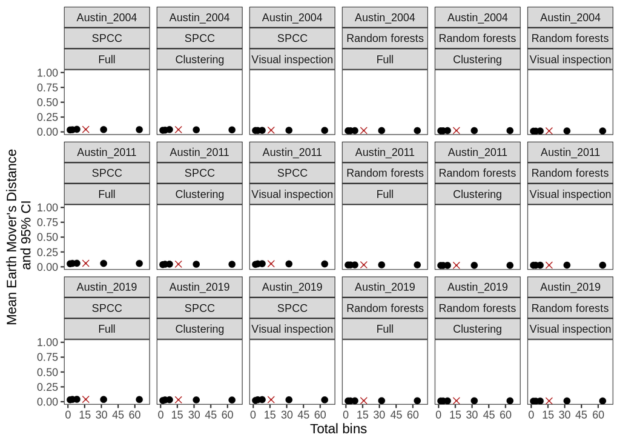

```r
# Austin: results for all bins summarized across resampling iterations. Also coloring the results to highlight the bin number used in the main table
emd_res %>%
  dplyr::filter(grepl("Austin", city_year)) %>%
  dplyr::mutate(
    similarity_method = factor(similarity_method, levels = c("SPCC", "Random forests")),
    dataset = factor(dataset, levels = c("Full", "Clustering", "Visual inspection"))
  ) %>%
  group_by(city_year, similarity_method, dataset, total_bins) %>%
  dplyr::summarise(
    mean = Rmisc::CI(EMD, ci = 0.95)[["mean"]],
    u_CI = Rmisc::CI(EMD, ci = 0.95)[["upper"]],
    l_CI = Rmisc::CI(EMD, ci = 0.95)[["lower"]]
  ) %>%
  dplyr::mutate(
    main_table = ifelse(total_bins == 16, "yes", "no"),
    main_table = factor(main_table, levels = c("yes", "no"))
  ) %>%
  ggplot(aes(x = total_bins, y = mean, color = main_table, fill = main_table, shape = main_table)) +
  geom_point(size = 2) +
  geom_errorbar(aes(ymin = l_CI, ymax = u_CI)) +
  scale_color_manual(values = c("firebrick", "black")) +
  scale_fill_manual(values = c("firebrick", "black")) +
  scale_shape_manual(values = c(4, 21)) +
  guides(color = "none", fill = "none", shape = "none") +
  facet_wrap(city_year + similarity_method ~ dataset, nrow = 3) +
  scale_y_continuous(limits = c(0, 1)) +
  scale_x_continuous(limits = c(0, 70), breaks = seq(0, 70, 15), labels = seq(0, 70, 15)) +
  ylab("Mean Earth Mover's Distance\n and 95% CI") +
  xlab("Total bins") +
  theme_bw() +
  theme(
    panel.grid.major = element_blank(),
    panel.grid.minor = element_blank()
  )
```

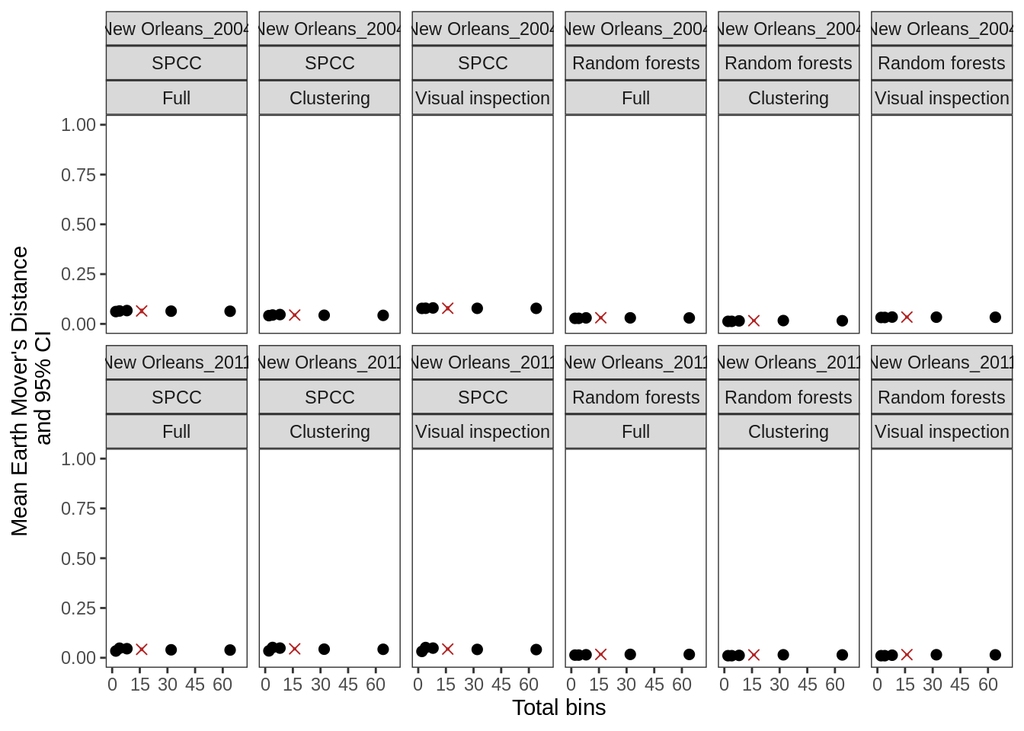

```r
# ggsave(file.path(gpath, "HierarchicalMapping_EMD_binSummary_AustinTemporal.tiff"), units = "in", width = 7.5, height = 5, dpi = 300)


# New Orleans: results for all bins summarized across resampling iterations. Also coloring the results to highlight the bin number used in the main table
emd_res %>%
  dplyr::filter(grepl("New Orleans", city_year)) %>%
  dplyr::mutate(
    similarity_method = factor(similarity_method, levels = c("SPCC", "Random forests")),
    dataset = factor(dataset, levels = c("Full", "Clustering", "Visual inspection"))
  ) %>%
  group_by(city_year, similarity_method, dataset, total_bins) %>%
  dplyr::summarise(
    mean = Rmisc::CI(EMD, ci = 0.95)[["mean"]],
    u_CI = Rmisc::CI(EMD, ci = 0.95)[["upper"]],
    l_CI = Rmisc::CI(EMD, ci = 0.95)[["lower"]]
  ) %>%
  dplyr::mutate(
    main_table = ifelse(total_bins == 16, "yes", "no"),
    main_table = factor(main_table, levels = c("yes", "no"))
  ) %>%
  ggplot(aes(x = total_bins, y = mean, color = main_table, fill = main_table, shape = main_table)) +
  geom_point(size = 2) +
  geom_errorbar(aes(ymin = l_CI, ymax = u_CI)) +
  scale_color_manual(values = c("firebrick", "black")) +
  scale_fill_manual(values = c("firebrick", "black")) +
  scale_shape_manual(values = c(4, 21)) +
  guides(color = "none", fill = "none", shape = "none") +
  facet_wrap(city_year + similarity_method ~ dataset, nrow = 2) +
  scale_y_continuous(limits = c(0, 1)) +
  scale_x_continuous(limits = c(0, 70), breaks = seq(0, 70, 15), labels = seq(0, 70, 15)) +
  ylab("Mean Earth Mover's Distance\n and 95% CI") +
  xlab("Total bins") +
  theme_bw() +
  theme(
    panel.grid.major = element_blank(),
    panel.grid.minor = element_blank()
  )
```

```r
# ggsave(file.path(gpath, "HierarchicalMapping_EMD_binSummary_NewOrleansTemporal.tiff"), units = "in", width = 7.5, height = 5, dpi = 300)
```

Make a figure and table of results for the main text.

```r
# Use an intermediate bin number since results are consistent across bins (within sampling iterations). I'm using 16 bins for the results that will go into another table in the main ms

# Make a plot for the main text
sum_stats_temp_df <- emd_res %>%
  dplyr::filter(total_bins == 16) %>%
  dplyr::mutate(
    city = gsub("_([0-9]+)", "", city_year),
    year = gsub("Austin_|New Orleans_", "", city_year)
  ) %>%
  group_by(city, year, dataset, similarity_method, total_bins) %>%
  dplyr::summarise(
    mean = round(Rmisc::CI(EMD, ci = 0.95)[["mean"]], 3),
    l_CI = round(Rmisc::CI(EMD, ci = 0.95)[["lower"]], 3),
    u_CI = round(Rmisc::CI(EMD, ci = 0.95)[["upper"]], 3)
  ) %>%
  ungroup() %>%
  dplyr::arrange(.,
    similarity_method, city, year, dataset
  ) %>%
  dplyr::select(similarity_method, city, year, dataset, mean, l_CI, u_CI, total_bins) %>%
  dplyr::mutate(
    year = as.numeric(year),
    similarity_method = factor(similarity_method, levels = c("Random forests", "SPCC"))
  )

glimpse(sum_stats_temp_df)
```

```
## Rows: 30
## Columns: 8
## $ similarity_method <fct> SPCC, SPCC, SPCC, SPCC, SPCC, SPCC, SPCC, SPCC, SPCC…
## $ city              <chr> "Austin", "Austin", "Austin", "Austin", "Austin", "A…
## $ year              <dbl> 2004, 2004, 2004, 2011, 2011, 2011, 2019, 2019, 2019…
## $ dataset           <fct> Full, Clustering, Visual inspection, Full, Clusterin…
## $ mean              <dbl> 0.042, 0.038, 0.029, 0.059, 0.045, 0.051, 0.039, 0.0…
## $ l_CI              <dbl> 0.039, 0.036, 0.027, 0.053, 0.041, 0.047, 0.036, 0.0…
## $ u_CI              <dbl> 0.045, 0.041, 0.031, 0.065, 0.049, 0.056, 0.043, 0.0…
## $ total_bins        <int> 16, 16, 16, 16, 16, 16, 16, 16, 16, 16, 16, 16, 16, …
```

```r
levels(sum_stats_temp_df$similarity_method)
```

```
## [1] "Random forests" "SPCC"
```

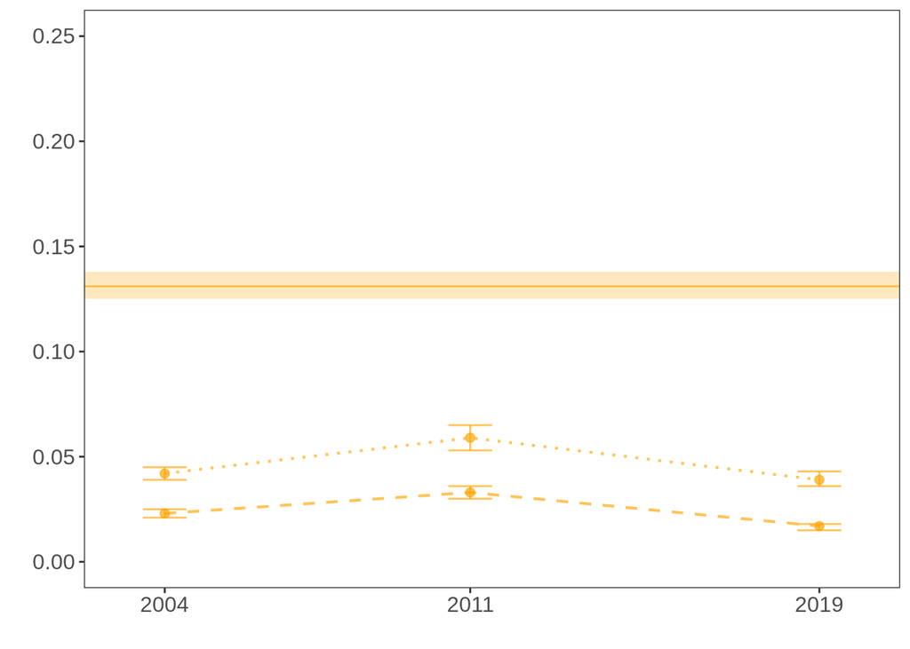

```r
clrs <- scales::alpha(c("orange"), 0.65)
# Random forests first (dashed), then SPCC (dotted)
ltys <- c("dashed", "dotted")

# A separate plot for Austin that shows 3 sampling years
ggplot() +
  geom_line(data = sum_stats_temp_df %>%
              dplyr::filter(city == "Austin") %>%
              dplyr::filter(dataset == "Full"),
            aes(x = year, y = mean, linetype = similarity_method, group = similarity_method), color = clrs, linewidth = 0.75) +
  geom_point(data = sum_stats_temp_df %>%
               dplyr::filter(city == "Austin") %>%
               dplyr::filter(dataset == "Full"),
             aes(x = year, y = mean), color = clrs, fill = clrs, size = 2) +
  geom_errorbar(data = sum_stats_temp_df %>%
                  dplyr::filter(city == "Austin") %>%
                  dplyr::filter(dataset == "Full"),
                aes(x = year, ymin = l_CI, ymax = u_CI), width = 1, color = clrs) +
  geom_hline(data = sum_stats_df %>%
               dplyr::filter(range == "Introduced range") %>%
               dplyr::filter(social_scale == "Individual"),
             aes(yintercept = mean), linetype = "solid", color = clrs) +
  geom_rect(data = sum_stats_df %>%
              dplyr::filter(range == "Introduced range") %>%
              dplyr::filter(social_scale == "Individual"),
            aes(xmin = -Inf, xmax = Inf, ymin = l_CI, ymax = u_CI), color = NA, fill = alpha(clrs, 0.25)) +
  scale_linetype_manual(values = ltys) +
  guides(color = "none", fill = "none", linetype = "none") +
  scale_y_continuous(limits = c(0, 0.25)) +
  scale_x_continuous(limits = c(2003, 2020), breaks = c(2004, 2011, 2019), labels = c("2004", "2011", "2019")) +
  ylab("") +
  xlab("") +
  theme_bw() +
  theme(
    panel.grid.major = element_blank(),
    panel.grid.minor = element_blank(),
    strip.background = element_blank(),
    strip.text = element_blank(),
    axis.text = element_text(size = 12)
  )
```

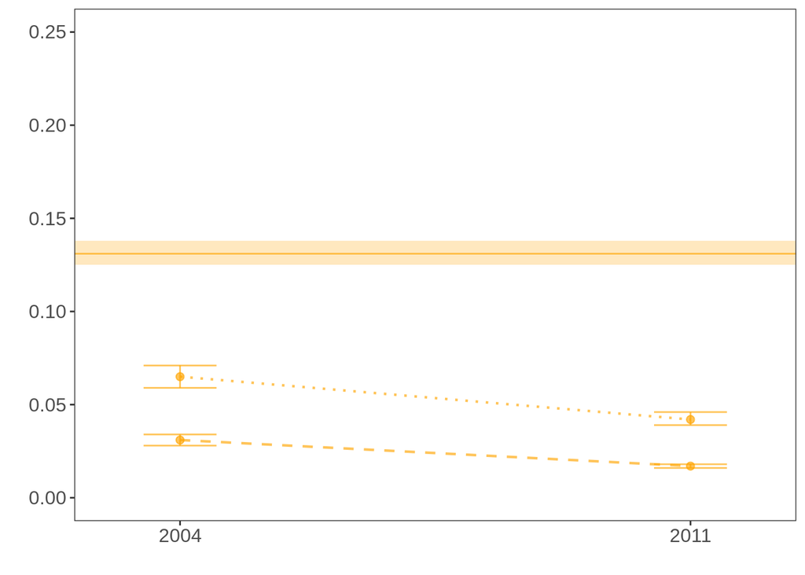

```r
# ggsave(file.path(gpath, "HierarchicalMapping_AustinTemporalComparison_EarthMoversDist.jpeg"), units = "in", width = 3, height = 2)

# A separate plot for New Orleans that shows 2 sampling years
ggplot() +
  geom_line(data = sum_stats_temp_df %>%
              dplyr::filter(city == "New Orleans") %>%
              dplyr::filter(dataset == "Full"),
            aes(x = year, y = mean, linetype = similarity_method, group = similarity_method), color = clrs, linewidth = 0.75) +
  geom_point(data = sum_stats_temp_df %>%
               dplyr::filter(city == "New Orleans") %>%
               dplyr::filter(dataset == "Full"),
             aes(x = year, y = mean), color = clrs, fill = clrs, size = 2) +
  geom_errorbar(data = sum_stats_temp_df %>%
                  dplyr::filter(city == "New Orleans") %>%
                  dplyr::filter(dataset == "Full"),
                aes(x = year, ymin = l_CI, ymax = u_CI), width = 1, color = clrs) +
  geom_hline(data = sum_stats_df %>%
               dplyr::filter(range == "Introduced range") %>%
               dplyr::filter(social_scale == "Individual"),
             aes(yintercept = mean), linetype = "solid", color = clrs) +
  geom_rect(data = sum_stats_df %>%
              dplyr::filter(range == "Introduced range") %>%
              dplyr::filter(social_scale == "Individual"),
            aes(xmin = -Inf, xmax = Inf, ymin = l_CI, ymax = u_CI), color = NA, fill = alpha(clrs, 0.25)) +
  scale_linetype_manual(values = ltys) +
  guides(color = "none", fill = "none", linetype = "none") +
  scale_y_continuous(limits = c(0, 0.25)) +
  scale_x_continuous(limits = c(2003, 2012), breaks = c(2004, 2011), labels = c("2004", "2011")) +
  ylab("") +
  xlab("") +
  theme_bw() +
  theme(
    panel.grid.major = element_blank(),
    panel.grid.minor = element_blank(),
    strip.background = element_blank(),
    strip.text = element_blank(),
    axis.text = element_text(size = 12)
  )
```

```r
# ggsave(file.path(gpath, "HierarchicalMapping_NewOrleansTemporalComparison_EarthMoversDist.jpeg"), units = "in", width = 2, height = 2)

# Combine the Austin and New Orleans plots in Inkscape
clrs # "#FFA500A6" the hexcode for making a legend in Inkscape
```

```
## [1] "#FFA500A6"
```

```r
# Making another table to be used in the supplement
emd_res %>%
  dplyr::filter(total_bins == 16) %>%
  dplyr::mutate(
    city = gsub("_([0-9]+)", "", city_year),
    year = gsub("Austin_|New Orleans_", "", city_year)
  ) %>%
  group_by(city, year, dataset, similarity_method, total_bins) %>%
  dplyr::summarise(
    mean = round(Rmisc::CI(EMD, ci = 0.95)[["mean"]], 3),
    l_CI = round(Rmisc::CI(EMD, ci = 0.95)[["lower"]], 3),
    u_CI = round(Rmisc::CI(EMD, ci = 0.95)[["upper"]], 3)
) %>%
  # Arrange to match ordering of Table 1 in the main text
  dplyr::arrange(.,
    similarity_method, city, year, dataset
  ) %>%
  dplyr::select(similarity_method, city, year, dataset, mean, l_CI, u_CI, total_bins) %>%
  kable(align = "c")
```

| similarity_method | city | year | dataset | mean | l_CI | u_CI | total_bins |
| --- | --- | --- | --- | --- | --- | --- | --- |
| SPCC | Austin | 2004 | Full | 0.042 | 0.039 | 0.045 | 16 |
| SPCC | Austin | 2004 | Clustering | 0.038 | 0.036 | 0.041 | 16 |
| SPCC | Austin | 2004 | Visual inspection | 0.029 | 0.027 | 0.031 | 16 |
| SPCC | Austin | 2011 | Full | 0.059 | 0.053 | 0.065 | 16 |
| SPCC | Austin | 2011 | Clustering | 0.045 | 0.041 | 0.049 | 16 |
| SPCC | Austin | 2011 | Visual inspection | 0.051 | 0.047 | 0.056 | 16 |
| SPCC | Austin | 2019 | Full | 0.039 | 0.036 | 0.043 | 16 |
| SPCC | Austin | 2019 | Clustering | 0.032 | 0.029 | 0.034 | 16 |
| SPCC | Austin | 2019 | Visual inspection | 0.034 | 0.032 | 0.036 | 16 |
| SPCC | New Orleans | 2004 | Full | 0.065 | 0.059 | 0.071 | 16 |
| SPCC | New Orleans | 2004 | Clustering | 0.044 | 0.041 | 0.048 | 16 |
| SPCC | New Orleans | 2004 | Visual inspection | 0.079 | 0.074 | 0.084 | 16 |
| SPCC | New Orleans | 2011 | Full | 0.042 | 0.039 | 0.046 | 16 |
| SPCC | New Orleans | 2011 | Clustering | 0.045 | 0.042 | 0.048 | 16 |
| SPCC | New Orleans | 2011 | Visual inspection | 0.044 | 0.041 | 0.046 | 16 |
| Random forests | Austin | 2004 | Full | 0.023 | 0.021 | 0.025 | 16 |
| Random forests | Austin | 2004 | Clustering | 0.023 | 0.021 | 0.025 | 16 |
| Random forests | Austin | 2004 | Visual inspection | 0.017 | 0.016 | 0.018 | 16 |
| Random forests | Austin | 2011 | Full | 0.033 | 0.030 | 0.036 | 16 |
| Random forests | Austin | 2011 | Clustering | 0.025 | 0.023 | 0.027 | 16 |
| Random forests | Austin | 2011 | Visual inspection | 0.028 | 0.026 | 0.030 | 16 |
| Random forests | Austin | 2019 | Full | 0.017 | 0.015 | 0.018 | 16 |
| Random forests | Austin | 2019 | Clustering | 0.015 | 0.014 | 0.017 | 16 |
| Random forests | Austin | 2019 | Visual inspection | 0.013 | 0.012 | 0.014 | 16 |
| Random forests | New Orleans | 2004 | Full | 0.031 | 0.028 | 0.034 | 16 |
| Random forests | New Orleans | 2004 | Clustering | 0.016 | 0.015 | 0.018 | 16 |
| Random forests | New Orleans | 2004 | Visual inspection | 0.034 | 0.032 | 0.036 | 16 |
| Random forests | New Orleans | 2011 | Full | 0.017 | 0.016 | 0.018 | 16 |
| Random forests | New Orleans | 2011 | Clustering | 0.015 | 0.013 | 0.016 | 16 |
| Random forests | New Orleans | 2011 | Visual inspection | 0.016 | 0.015 | 0.017 | 16 |

# References

```
1. Smith-Vidaurre, G., Araya-Salas, M., and T.F. Wright. 2020. Individual signatures outweigh social group identity in contact calls of a communally nesting parrot. Behavioral Ecology 31(2), 448-458. https://doi.org/10.1093/beheco/arz202

2. Smith-Vidaurre, G., Perez-Marrufo, V., & Wright, T. F. 2021. Individual vocal signatures show reduced complexity following invasion. Animal Behavior, 179, 15–39. https://doi.org/10.1016/j.anbehav.2021.06.020

3. Rubner, Y., Tomasi, C., & Guibas, L. J. 2000. The Earth Mover’s Distance as a metric for image retrieval. International Journal of Computer Vision, 40(2), 99.
```